# R bootcamp - part 4: data processing with dplyr

Hannah Meyer

September 2025

# 1 Introduction

In the previous tutorials, you have learned how to visualise your data, from simple scatter plots with default settings to compound figures with elaborate color schemes and labels. For all of these, we used the data from (Smith et al. 2004) (made available at the following http://www.antigenic-cartography.org/). I mentioned briefly in the previous exercises, that I had formated the data for us to work with. What I expressed there in a half-sentence, usually contains a lot of work, often more than the actual analysis: cleaning your data, bringing it into the right format, checking it for sanity. In the following sections, we will learn how to use `dplyr` to reformat data into a ‘tidy’ format that we can use for visualisation and analysis.

For a more detailed description and additional examples, refer to chapter 5 in Hadley Wickham book ‘R for Data Science’ (Wickham and Grolemund 2017). I would generally highly recommend this book, as it introduces concepts we have discussed in this course and beyond - its online version is available for free [here](https://r4ds.had.co.nz/)!

In addition, for an overview and help on `dplyr` functions take a look at the `dplyr` cheat sheet accessible by choosing *Help* > *Cheatsheets* > *Data Transformation with `dplyr`* in the RStudio tool bar.

# 2 Set-up

First, we are going to set up our analysis script,

```
knitr::opts_chunk$set(echo = TRUE,
                      comment = "#>",
                      collapse = TRUE,
                      fig.width = 6,
                      fig.align = "center",
                      fig.pos = 'h',
                      out.width = "70%")
```

load the required libraries

```
library("forecats")
```

[output not shown]

# 3 dplyr: a grammar of data manipulation

The `dplyr` package is a core member of the tidyverse. Its main functionality relies on six functions that let us solve the majority of data reformating. These functions, often described as the `verbs for the language of data manipulation’, are:

- `arrange()`: to change the order of observations;
- `select()`: to select a subset of variables;
- `mutate()`: to add new variables that are functions of existing variables;
- `filter()`: to subset observations based on their values;
- `summarise()`: to summarise observations to a single row;
- `group_by()`: to change the unit of analysis from the complete dataset to individual groups.

All verbs work in a similar fashion:

- their first argument is a `tibble` or `data.frame`;
- the following arguments describe the action to apply to that `tibble`/`data.frame` by specifying the variable names
- the result is a new `tibble`/`data.frame`, dependent on the initial input

**Note**: If you want to save the results of a `dplyr` function, you have to use the assignment operator `<-`, as `dplyr` functions never modify their input data.

## 3.1 Change the order of observations with `arrange()`

Using `arrange()`, we can change the order of rows. As input, `arrange` takes a `tibble` and a set of variable names - at least one is required. It will re-arrange the observations of the `tibble` based on variable selected for re-ordering. If you provided more than one variable to order the tibble by, each additional variable will be used to break ties in the values of preceding variables.

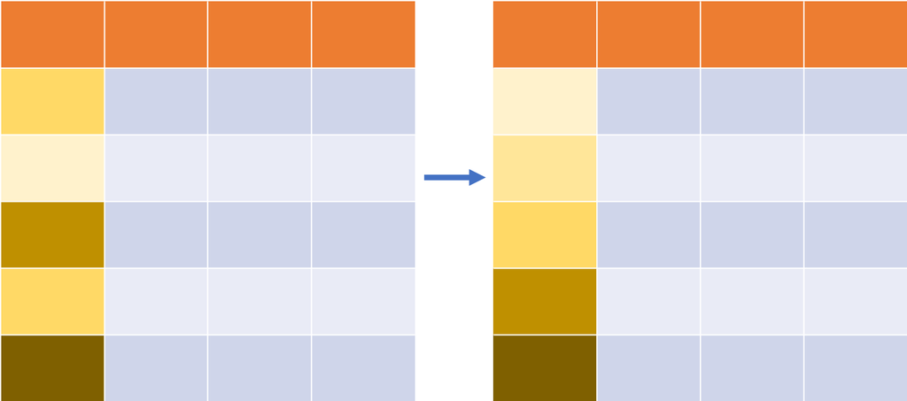

**Note**: These visualisations for `dplyr` verb function are inspired by the `dplyr` cheat sheet.

### 3.1.1 Exercises

1. How does the ouput change if you sorted by year first, then location?
2. Sort `coord` to find when the last virus was isolated.
3. Find the largest and smallest x.coordinate in the dataset.

## 3.2 Select a subset of variables with `select()`

`select()` let’s us pick a subset of variables. In the most simple case, we specify the `tibble` from which we want to `select()` variables, followed by the names of the variables that we want to pick.

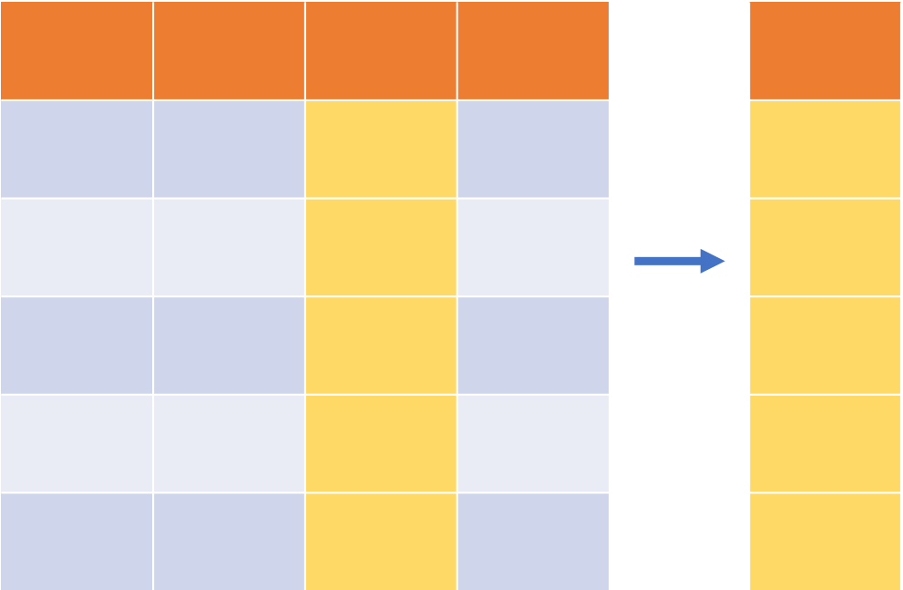

In addition to that, there a number of functions that can be used in conjunction with `select()` that let us select multiple variables with common elements in their name. These include:

- `starts_with("year")`: matches names that begin with “year”.
- `ends_with("coordinate")`: matches names that end with “coordinate”.
- `contains("coord")`: matches names that contain “coord”.
- `num_range("X", 1:3)`: matches X1, X2 and X3.
- `everything()`: matches everything that has not specifically been named before (see Exercises to mutate for example).

### 3.2.1 Exercises

1. What are two other ways of only selecting the `x.coordinate` and `y.coordinate` columns?
2. Can you use `select` to move the `location` variable from second column to last?

## 3.3 Add new variables with `mutate()`

To add new variables to a `tibble`, we use `mutate`. Again, `mutate` first expects the name of the `tibble` to which we want to add a variable, followed by the name of the new variable, an equal sign `=` and the data to add. The data has to have the same number of observations as our input `tibble` and can be created by using a transformation of an existing variable.

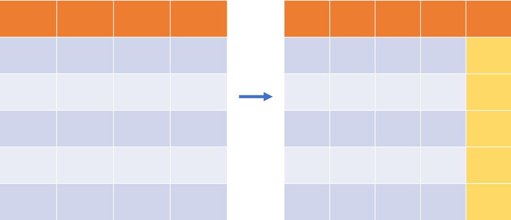

**Note**: `mutate()` adds the column at the end of the `tibble`; if you want it at a different position use `select` to reorder the variables afterwards.

### 3.3.1 Exercises

1. Add a new column that contains the time difference between this year, 2020, and the year the virus was isolated.
2. Save the result of this `mutate` in a new object.
3. Move the new column between the `year` and `cluster` columns.

## 3.4 Select of subset of observations with `filter()`

`select` creates a subset of the input data by selecting variables. `filter()` allows us to subset our input data by observations. As a first argument it takes the name of the `tibble`; this is followed by expressions that filter observations based on their value in the specified variables. Filtering uses the standard set of comparison operators available in R.

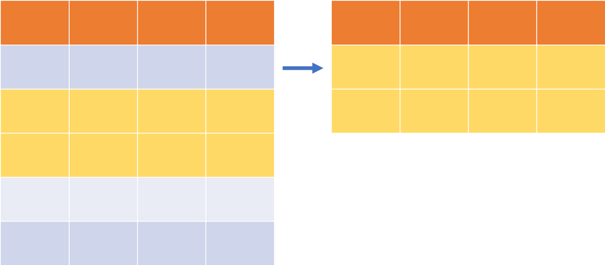

### 3.4.1 Comparisons

Comparison operators in R:

- `==`: equal to
- `!=`: not equal to
- `>`: greater than
- `>=`: greater or equal than
- `<`: less than
- `<=`: less or equal than

**Note**: When testing for equality, make sure to use `==` and not a simple `=`!

Any more complicated combinations, like in circulation before 1988 but not in BILTHOVEN and not in MADRID, can be constructed using the logical operators *and* `&`, *or* `|` and *not* `!`. The graphic below shows a complete overview of selection logical subsets of observations for two variables “red” and “blue”:

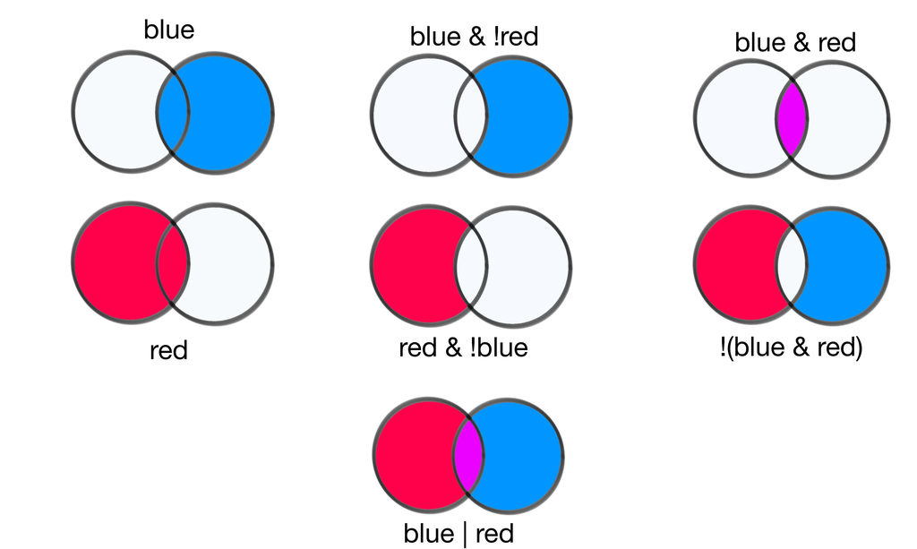

where we select every row where `x`, in this case location, is contained in `y`, here a vector of names.

**Note**: vectors are R data objects and are constructed by enclosing the variables`x`, `y`, `z` to be put in the vector in `c()`: `c(x,y,z)`

### 3.4.2 Exercises

1. Find viruses whose isolation is specified as NETHERLANDS.
2. Filter for rows that are of type antigen (AG).
3. Find viruses in circulation after 1997 and are assigned to either cluster SY97 or cluster WU95.

## 3.5 Group analyses and summarise observations with `group_by` and `summarise()`

`group_by` and `summarise()` often go hand in hand: using `group_by`, we can first group observation based on values in the specified variable and then apply a summary statistic on this group. This might sound a bit complicated, so let’s have a look at an example. We are fist going to group `coord` by cluster. To pass this grouped `tibble` onto the `summarise` function, we have to save the grouped `tibble` into a new object (for now, we will see further down how we can do this more elegantly). We pass this new object to `summarise`, to find the start and end year of circulation for viruses per cluster.

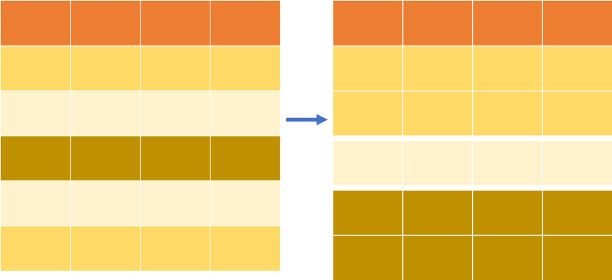

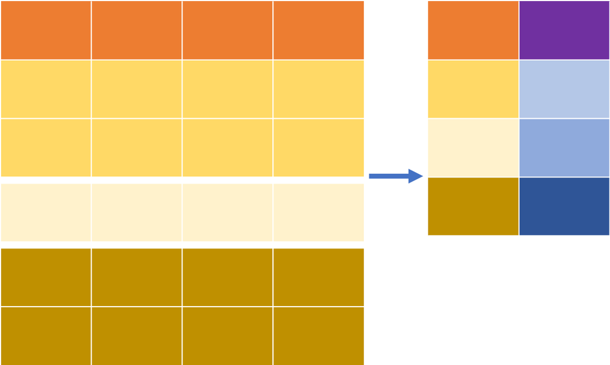

Functions used with `summarise` have to return a single value. Other useful functions are for instance:

- `mean`: returns mean value;
- `median`: returns median values;
- `sum`: return the sum of input values;
- `n()`: returns total count (this is the only one that does not take an argument);
- `n_distinct`: returns the unique count;

### 3.5.1 Exercises

1. How do you know if a `tibble` is grouped or not? How do you ungroup a grouped `tibble` (Hint: use the help function of `group_by`).
2. What happens if you use the same `summarise` command on the original, ungrouped `tibble`?
3. Find the mean x and y coordinate of each cluster.
4. Find the total and distinct number of locations per cluster.

# 4 Creating a workflow with pipes

where we pipe `coord` into the grouping function, and then pipe the output of that into the summarise function.

This is really powerful and elegant, when we have to apply many processing steps to our data and want to avoid having to create lot’s of intermediate objects.

## 4.1 Exercises

1. Create a piped workflow that finds the number of distinct clusters and the first virus isolation for each location.

# 5 References

Smith, Derek J., Alan S. Lapedes, Jan C. de Jong, Theo M. Bestebroer, Guus F. Rimmelzwaan, Albert D. M. E. Osterhaus, and Ron A. M. Fouchier. 2004. “Mapping the Antigenic and Genetic Evolution of Influenza Virus.” *Science* 305 (5682): 371–76. https://doi.org/10.1126/science.1097211.

Wickham, Hadley, and Garrett Grolemund. 2017. *R for Data Science: Import, Tidy, Transform, Visualize, and Model Data*. 1st ed. O’Reilly Media, Inc. https://r4ds.had.co.nz/.